# Global burden of bacterial antimicrobial resistance in 2019: a systematic analysis

Wei-Ming Jiang

2024-08-13

## Summary

The study estimated deaths and disability-adjusted life-years (DALYs) attributable to and associated with bacterial AMR for 23 pathogens and 88 pathogen–drug combinations in 204 countries and territories in 2019.

Their approach can be divided into five broad components:

1. number of deaths where infection played a role 因感染造成的死亡數量
2. proportion of infectious deaths attributable to a given infectious syndrome 因為特定感染症候群造成死亡的比例
3. proportion of infectious syndrome deaths attributable to a given pathogen 特定病原體導致的感染症候群死亡比例
4. the percentage of a given pathogen resistant to an antibiotic of interest 特定病原體對特定抗生素具有抗藥性的百分比
5. the excess risk of death or duration of an infection associated with this resistance 與這種抗藥性相關的死亡或感染持續時間的超額風險

Using these components, they estimated disease burden based on two counterfactuals:

1. deaths attributable to AMR (based on an alternative scenario in which all drug-resistant infections were replaced by **drug-susceptible infections**)
2. deaths associated with AMR (based on an alternative scenario in which all drug-resistant infections were replaced by **no infection**)

We generated 95% uncertainty intervals (UIs) for final estimates as the 25th and 975th ordered values across 1000 posterior draws, and models were cross-validated for out-of-sample predictive validity.

## Methods

### Overview

We developed an approach for estimating the burden of AMR that makes use of all available data and builds on death and incidence estimates for different underlying conditions from the Global Burden of Diseases, Injuries, and Risk Factors Study (GBD) 2019, which provides age-specific and sex-specific estimates of disease burden for 369 diseases and injuries in 204 countries and territories in 1990–2019. [14]

Our approach can be divided into **ten estimation steps** that occur within five broad modelling components. [a flowchart in the appendix p.123]

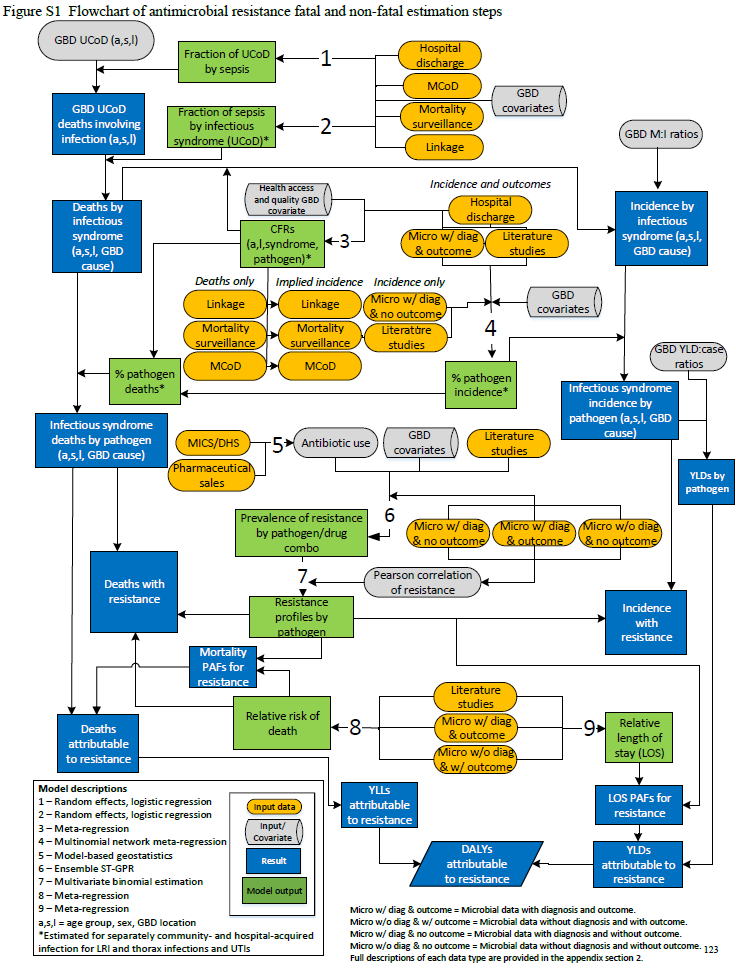

We obtained data from multiple data sources, including from **published studies** (eg, microbiology data, inpatient data, data on multiple causes of death, and pharmaceutical sales data) and directly from **collaborators** on the Global Research on Antimicrobial Resistance project,15 members of the GBD Collaborator Network, and other data providers.

### Input data

The diverse data sought included the following sources (all sources are listed by data type in the appendix pp 8–15):

1. pharmaceutical companies that run surveillance networks, diagnostic laboratories, and clinical trial data
2. high-quality data from researchers including large multisite research collaborations, smaller studies, clinical trials, and well established research institutes based in low-income and middle-income countries (LMICs)
3. data from public and private hospitals and public health institutes providing diagnostic testing
4. global surveillance networks; enhanced surveillance systems; national surveillance systems
5. surveillance systems for specific organisms such as *Mycobacterium tuberculosis* and *Neisseria gonorrhoeae*

Figure 1 shows a summary of the distinct data types gathered and for which estimation step each data type was used.

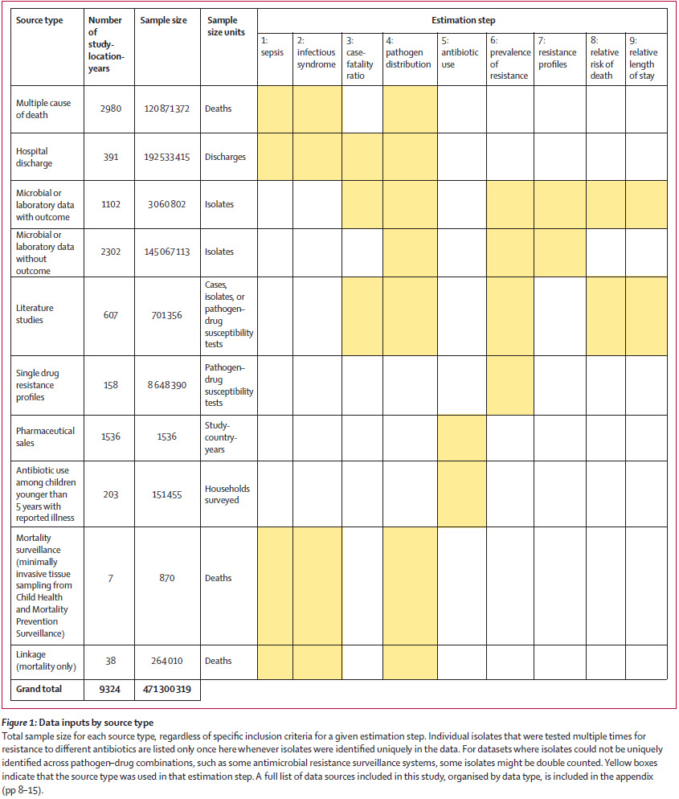

### Estimation steps one and two: deaths in which infection played a role by infectious syndrome

First, to define the number of deaths where infection plays a role, we used GBD 2019 cause of death estimates [14] to determine the number of deaths by age, sex, and location for which either the underlying cause of death was infectious or—for non-communicable, maternal, neonatal, nutritional, and injury deaths—for which the pathway to death was through sepsis. 以GBD 2019死因資料來決定各年齡、性別、地區的死因資料

**underlying cause of death**

defined by the World Health Organization (WHO) as the disease or injury that initiated the train of events leading directly to death, or the circumstances of the accident or violence which produced the fatal injury.

**Sepsis**

a life-threatening organ dysfunction due to a dysregulated host response to infection [23]

`Purpose` The methods used to estimate **infectious underlying causes of death and sepsis deaths** have been published previously [14,24] and are summarised in the appendix (pp 17–18). 估計感染死因和敗血症死亡

We then multiplied **the fraction of sepsis** predicted from the logistic regression models onto **GBD causespecific mortality estimates** to determine the **mortality envelope** for our analysis.

`Result` Our mortality envelope consisted of **all deaths in which infection played a role**, which included all sepsis deaths with noninfectious underlying causes, plus all deaths with an infectious underlying cause in GBD 2019 (appendix pp 21–23).

#### Input data

1. Multiple causes of death (MCoD)

   MCoD data are **individual-based records** that provide underlying causes of death and two or more intermediate causes in the chain of death. Additionally, each record includes **age, sex, residence, and the date of death**. 死因資料包含年齡、性別、居住地和死亡日期
2. Hospital record with multiple diagnoses and discharge status of death

   This type of data is an **individual-based hospital record of a patient** that provides the main diagnosis and two or more additional diagnoses. Additionally, each record includes **age, sex, residence, date of admission, date of discharge, and outcome (dead or alive)**. **Only hospital discharges with discharge status of death were used in this component model**, since we aimed to estimate the fraction of deaths that involve infection and the infectious syndrome distribution of those deaths. 醫院紀錄包含年齡、性別、居住地、入院日期、出院日期，只有死亡的個案納入此模型當中
3. Linkage data

   Linkage data are generated using probabilistic methods in a defined population that link individual-based hospital data to individual-based MCoD data. Linkage data offer a wider dataset that includes **main diagnosis, other diagnoses, underlying cause of death, and intermediate causes of death in the chain**. 將個人醫院資料與個人死因資料做連結，連結資料提供了主要診斷、死因、死亡的中間原因
4. Mortality surveillance (Child Health and Mortality Prevention Surveillance [CHAMPS])

   The CHAMPS network tracks **the causes of under-5 mortality and stillbirths at sites** **in sub-Saharan Africa and south Asia**. 在撒哈拉以南非洲與南亞五歲以下、死產死因

#### Data processing

Data for the USA, Brazil, Italy, South Africa, and Mexico were extracted **at the subnational level by GBD 2019 age groups, sex, year, and causes of death and/or diagnoses**, while data for the remaining countries and territories were analysed **at the national level**. This allowed us to expand the location-years of data that we had for each Sociodemographic Index (SDI) [12] value. 在美國、巴西、義大利、南非與墨西哥以次國家層級的空間尺度分析GBD資料，其餘地區以國家層級作分析

#### First pathway: deaths where infection plays a role - Sepsis model

We used a **mixed-effects binomial logistic regression** to model the logit of the fraction of sepsis-related deaths by GBD cause-age-sex-location, consistent with the modelling approach used by Rudd et al. [13]

**Sex** and **Healthcare Access and Quality Index (HAQ Index)** [14] were included as covariates and **a nested random effect** on underlying cause of death was included. 將性別和HAQ Index作為共變量，並在死因加上random effect

**HAQ Index**

HAQ Index construction methods were updated to use **the arithmetic mean of scaled mortality-to-incidence ratios (MIRs) and risk-standardised death rates (RSDRs)** for 32 causes of death that should not occur in the presence of timely, quality health care. 死亡率與發病率的比例和風險標準化死亡率的算術平均值

A separate model was run for each GBD 2019 age group (0–6, 7–27, 28-364 [days], 14, 5–9, 10–14, 15–19, 20–24, 25–29, 30–34, 35–39, 40–44, 45–49, 50–54, 55–59, 60–64, 65–69, 70–74, 75–79, 80-84, 85–89, 90–94, 95+ [years]): 根據年齡分別跑模型

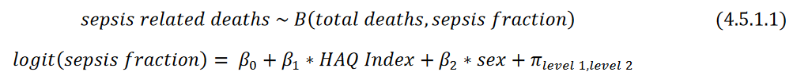

Where **𝜋 level 1,level 2 is a nested random effect on underlying cause of death**. The nested random-effect’s structure in the model on underlying cause of death allowed the prediction of sepsis fractions where data were limited by borrowing information from diseases within the same group.

We produced our predictions and uncertainty intervals (UIs) by generating **1000 draws** from the normal distribution of the fixed coefficients, separately for each GBD location, age group, sex, and cause in 2019. The means of our results were used for the point estimates and the **95% UIs** were delineated using the 2.5th and 97.5th percentiles of the draws.

#### Second pathway: fraction of deaths where infection plays a role by infectious syndrome in each GBD cause

In estimation step two, we used details on the pathways of disease provided in **multiple causes of death** and **hospital discharge data** in a **second stage of random effects logistic regression models** to further **subdivide deaths in which infection played a role into 12 major infectious syndromes and one residual category**. 根據死因資料和醫院資料，再建立模型將感染所造成的死亡區分為12種主要感染症候群及1種類別

These regressions predicted **the proportion of sepsis-related deaths** that were caused by a given infectious syndrome separately for each communicable, maternal, neonatal, and nutritional underlying cause of death; non-communicable underlying cause of death; and injury underlying cause of death. 這模型預測各種死因與敗血症相關死亡的比例

The model covariates varied by infectious syndrome (table 4.6.1). All models included **HAQ Index** as a covariate and most included a **summary exposure value** (SEV) scalar calculated for GBD 2019. 依據各種感染症候群模型所使用的共變量不同，主要都包含了HAQ index，多數包含SEV

**summary exposure value (SEV)**

A measure of a population’s exposure to a risk factor that takes into account the extent of exposure by risk level and the severity of that risk’s contribution to disease burden.

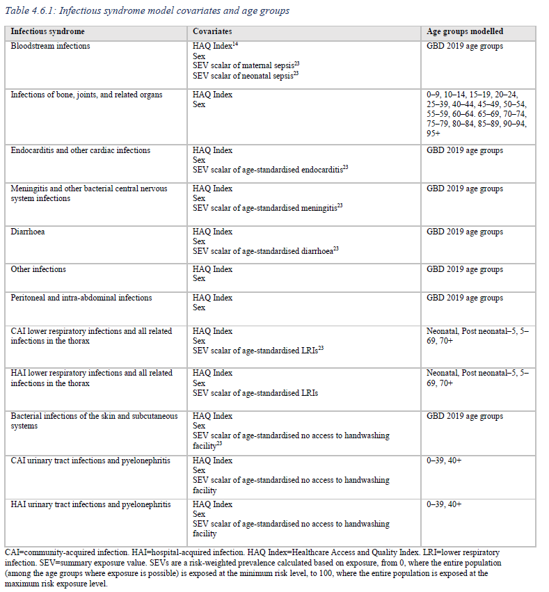

Due to the pathogen distributions varying substantially for **hospital-acquired** and **community-acquired infections** in two infectious syndromes—lower respiratory and thorax infections and urinary tract infections—we further estimated the subdivision of these syndromes into community-acquired and hospital-acquired infections. 因為病原體分布在「下呼吸道和胸部感染」與「泌尿道感染」的院內感染與社區感染變化很大，所以後續根據院內與社區感染分別估計

The infectious syndrome models were specified as **mixed-effects binomial logistic regressions**, one for each infectious syndrome and age group: 根據每一個感染症候群和年齡層分別建立模型

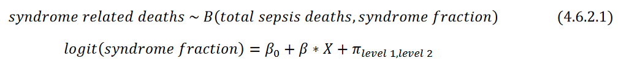

where 𝛽 and 𝑋 are vectors of length n + 1 for n covariates and 𝜋 level 1,level 2 is a nested random effect on underlying cause of death. The granularity of the age groups estimated for each infectious syndrome was chosen based on the age pattern of the infectious syndrome and the limitations of data sparsity.

### Estimation steps three and four: pathogen distribution for deaths and incident cases

To estimate the **pathogen distribution of each infectious syndrome** separately for deaths and incident cases for each age, sex, and location, we made use of multiple data sources. 為了死亡與發病個案，分別估計每個感染症候群的病原體分布

#### For estimation step three

We took data that linked pathogen-specific disease incidence to deaths to develop models for **pathogen-specific CFRs** that varied by age, location, and syndrome. 依據年齡、地區與症候群估計特定病源體的致死率

**CFRs**

case-fatality ratios

We used the **Bayesian meta-regression tool MR-BRT** [29] to estimate CFRs as a function of the Healthcare Access and Quality Index and various bias covariates (appendix pp 31–34). [21]

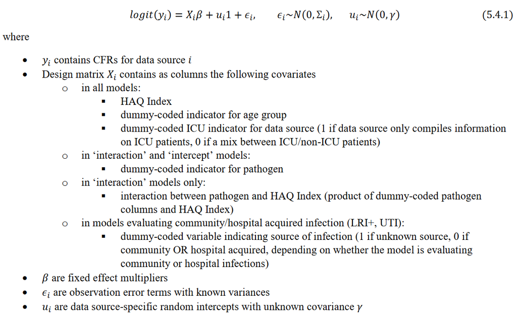

#### For estimation step four

To incorporate all these heterogeneous data, we used a new modelling environment, termed **multinomial estimation with partial and composite observations**. This modelling environment allows for **the inclusion of covariates in the network analysis** [29] and for **Bayesian prior probability distributions to be incorporated**. 這一個模型環境可以在網絡分析中包含共變數，也可以納入貝氏先驗機率分佈

To model the **infectious syndrome pathogen distribution** comprehensively, we estimated, where applicable, the incidence and death proportions attributable to viral, fungal, parasitic, and bacterial pathogens; 為了模擬感染症候群病原體的分佈，估計了病毒、真菌、寄生蟲和細菌病原體的發病率和死亡率比例

however, AMR burden was calculated only for selected bacteria for which resistance is clinically relevant and sufficient data are available. More details on this approach are provided in the appendix (pp 34–44). AMR 負擔僅針對抗藥性與臨床相關且有足夠數據可用的選定細菌進行計算

##### Input data

1. Multiple causes of death data
2. Hospital discharge
3. Linkage data
4. Microbial data with and without outcome information 微生物數據
5. Literature studies from the aetiology literature reviews 病因文獻回顧
6. Mortality surveillance (Child Health and Mortality Prevention Surveillance [CHAMPS])

### Estimation steps five to seven: prevalence of resistance by pathogen

We used data from 52·8 million isolates to analyse **the proportion of phenotypic AMR for each pathogen**—the proportion of infections that were drug resistant, hereafter referred to as prevalence of resistance—for 88 pathogendrug combinations. 計算每種病原體表型 AMR 的比例，總共有88種病原體藥物組合

The number of positive isolates identified for each pathogendrug combination is shown in the appendix (pp 90–91). 這些組合在附錄90-91頁

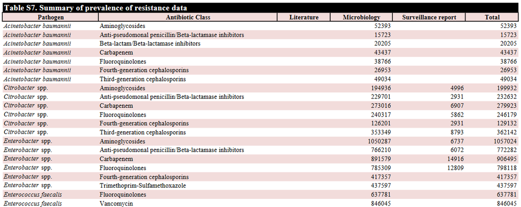

We used two categories of susceptibility: susceptible and non-susceptible. The non-susceptible group includes isolates reported as “non-susceptible”, “intermediate”, and “resistant”. 敏感度分成兩類：易感性和非易感性。非易感組包括報告為「非易感」、「中間」和「抗藥性」的分離株

To account for bias in resistance data provided by tertiary care facilities, we adjusted tertiary rates of resistance by crosswalking them to data from non-tertiary and mixed facilities using MR-BRT as described in the appendix (pp 45–48). [31] 為了計算三級照護機構提供的抗藥性資料的偏差，使用MR-BRT模型將其資料與三級、混合照護機構的資料做整合調整

We used a **two-stage spatiotemporal modelling framework** to estimate the **prevalence of resistance in each pathogen–drug combination** by location for 2018. 使用兩階段時空模型架構按地點劃分估計每種病原體-藥物組合的抗藥性率

we were unable to collect more contemporary data; we assumed no change in prevalence of resistance for 2019. 因為無法取得即時資料所以假設2019年的資料沒有改變

First, we fitted a **stacked ensemble model** between the input data and selected covariates from the list of plausible and health-related covariates available in GBD 2019 (appendix pp 48–49, 92–93). 資料與選擇共變數建立堆疊整合模型，特定共變數舉例：

1. Mean temperature
2. Pigs per capita 人均生豬數：as a proxy for antibiotic use in animal husbandry
3. Population density
4. Oral rehydration 口服補液 (適量的糖和鹽（特別是鈉、鉀）的水)

The estimates from the stacked ensemble model were then inputted into a **spatiotemporal Gaussian process regression model** [31] to smooth the estimates in space and time. 將堆疊整合模型的估計結果輸入到時空高斯過程迴歸模型得到在時空上的平滑估計

Given the strong relationship between antibiotic consumption levels and the proliferation of resistance, we modelled antibiotic consumption at the national level to use as a covariate in the stacked ensemble model of prevalence of resistance. 因為抗生素消費水平與抗藥性擴散之間的密切關係，所以對國家層面的抗生素消費進行了建模，以用作抗藥性流行的堆疊整合模型中的共變量。

We analysed data from **65 Demographic and Health Surveys** and **138 Multiple Indicator Cluster Surveys** using modelbased geostatistics to quantify antibiotic usage in LMICs. 使用上述資料以地理統計量化中低收入國家抗生素的使用

**LMICs**

Low- and middle-income countries

These LMIC-specific estimates of antibiotic usage were combined with pharmaceutical sales data from IQVIA, WHO, and the European Centre for Disease Prevention and Control (ECDC) by use of an ensemble **spatiotemporal Gaussian process regression model** to produce a **location-year covariate on antibiotic consumption** for all 204 countries and territories included in this study. [22] 整合中低收入國家抗生素使用資料+藥品銷售數據，建立時空高斯過程迴歸模型估計 204 個國家和地區抗生素消費量的地點-年份共變量

Additional details on our estimation method for prevalence of resistance are available in the appendix (pp 44–53).

To account for **multidrug resistance**, we used linelevel microbiology data that tested multiple antibiotics for the same isolate to produce **Pearson correlation coefficients** of the co-occurrence of resistance to different antibiotics. 為了解釋多重抗藥性，我們使用線級微生物學數據測試同一分離株的多種抗生素，計算對不同抗生素產生共同抗藥性的皮爾森相關係數

With these Pearson correlations and our prevalence of resistance estimates, we used an **optimisation-based approach** to solve for multivariate binomial distributions that define the prevalence of resistance of every combination of resistance to the antibiotics analysed. 利用皮爾森相關性和抗藥性盛行率的估計，使用最佳化的方法來求解多元二項分佈，該分佈定義了每種抗藥性組合的抗藥性盛行率

Every such distribution was characterised by a contingency table specifying probabilities of all combinations of resistance and susceptibility among the antibiotics analysed. 每個這樣的分佈都由一個列聯表來表徵，該列聯表指定了所分析的抗生素中所有抗藥性和敏感性組合的機率。

We optimised over the space of such contingency tables to find the nearest feasible distribution given the data, producing, for each pathogen, a set of resistance profiles: the proportions of bacteria with each combination of resistance and susceptibility among all the antibiotics analysed (appendix pp 48–49). 對此類列聯表的空間進行了最佳化，以找到給定資料的最接近的可行分佈，為每種病原體產生一組抗藥性概況：在所有分析的抗生素中具有每種抗藥性和敏感性組合的細菌的比例

### Estimation steps eight and nine: relative risk of death for drug-resistant infection compared with drug-sensitive infections

Using data from 164 sources representing 511870 patients with known outcome and resistance information, we estimated **the relative risk of death for each pathogen-drug combination** for a resistant infection compared with that of a drug-sensitive infection using **MR-BRT**. 以MR-BRT模型估計每一個病原體藥物組合的死亡相對風險，比較抗藥性感染和藥物敏感感染

Because of data sparsity, we assumed the relative risk was the same for every syndrome, location, and age group. 因為資料稀疏，假設每個綜合症、地點和年齡組的相對風險都是相同

We used a **two-stage nested mixed effects meta-regression model** to estimate relative risk of death for each pathogen–drug combination that was adjusted for age, admission diagnosis, hospital-acquired versus community-acquired infection, and site of infection (appendix pp 54–56). 利用模型估計每種病原體-藥物組合的死亡相對風險，依年齡、入院診斷、院內感染與社區型感染、感染部位進行調整

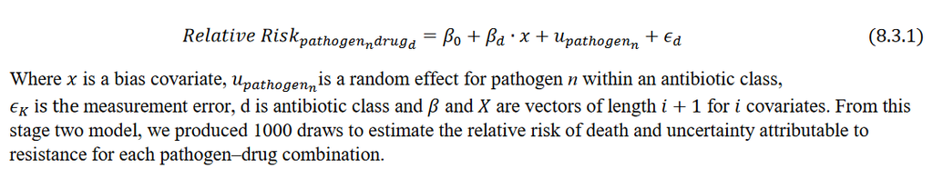

To produce burden estimates of multiple pathogen-drug combinations that were mutually exclusive within a given pathogen, we produced a **population-attributable fraction (PAF)** for each resistance profile with resistance to at least one drug (appendix pp 56–60). 為了對特定病原體內相互排斥的多種病原體藥物組合進行負荷估計，為每種抗藥性情況計算群體歸因分數 (PAF)

**PAF**

The PAF represents the **proportional reduction in deaths or years lived with disability (YLDs)** that would occur if all infections with the resistance profile of interest were instead susceptible to all antibiotics included in the analysis. **PAF** 代表死亡或殘疾壽命 (YLD) 的比例減少，如果所有具有相關抗藥性的感染都對分析中包含的所有抗生素敏感，則會出現這種情況

When two or more antibiotics were resistant in a single profile, we used the relative risk for the antibiotic class that was the largest as the relative risk for calculating the PAF: 當單一資料中兩種或多種抗生素具有抗藥性時，使用最大抗生素類別的相對風險作為計算 PAF 的相對風險：

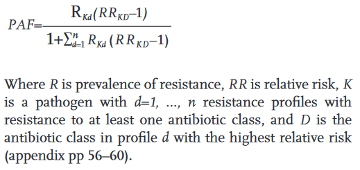

### Estimation step ten: computing burden attributable to drug resistance and burden associated with drug-resistant infections

We computed two counterfactuals to estimate the drug-resistant burden (appendix pp 56–60):

1. the burden **attributable to** bacterial AMR based on the counterfactual of drug-sensitive infection 基於藥物敏感感染反事實，可歸因於細菌抗生素抗藥性的負擔
2. the burden **associated with** bacterial AMR based on the counterfactual of no infection 基於無感染反事實，與細菌抗生素抗藥性相關的負擔

Briefly, to estimate **the burden attributable to AMR**, we first calculated **the deaths attributable to resistance** by taking the product of deaths for each underlying cause, the proportion of these deaths in which infection played a role, the proportion of infectious deaths attributable to each infectious syndrome, the proportion of infectious syndrome deaths attributable to each pathogen, and the mortality PAF for each resistance profile. 為了計算可歸因於細菌抗生素抗藥性的負擔，首先計算可歸因於抗藥性的死亡，將所有前面的計算結果相乘

We used previously described GBD methods [14] to **convert age-specific deaths into years of life lost (YLLs)** using the standard counterfactual life expectancy at each age. [34] 使用每個年齡的標準反事實預期壽命，將特定年齡的死亡轉化為壽命損失年數 (YLLs)

**YLLs**

Years of life lost

To calculate attributable YLDs, we took the product of **the infectious syndrome incidence**, **the proportion of infectious syndrome incident cases attributable to each pathogen**, **YLDs per incident case**, and **the non-fatal PAF**. 為了計算attributable YLDs，將感染症候群發生率、可歸因於每種病原體的感染症候群病例比例、每個病例的 YLDs 以及非致命性 PAF 相乘

**YLDs**

Years of healthy life lost due to disability

For resistance profiles that had resistance to more than one antibiotic class, we redistributed burden to the individual antibiotic classes proportionally on the basis of excess risk, providing a mutually exclusive burden for each pathogen–drug combination (appendix pp 56–60). 針對一種抗生素類別以上的抗藥性，根據超額風險按比例將負擔重新分配給各個抗生素類別，為每種病原體-藥物組合提供相互排斥的負擔

To calculate DALYs, we took the sum of YLLs and YLDs.

**Disability-adjusted life years (DALYs)**

a measure of overall disease burden, expressed as the number of years lost due to ill-health, disability, or early death.

To estimate the overall AMR burden of the drug-sensitive counterfactual, we added the burden estimates of all the pathogen–drug combinations. 為了估計藥物敏感反事實的總體 AMR 負擔，加入所有病原體-藥物組合的負擔估計

The approach for calculating the fatal burden associated with AMR was identical to that for fatal burden attributable to AMR, except we **replaced the mortality PAF for each resistance profile with the prevalence of resistance in deaths**. 計算與抗菌素抗藥性相關的致命負擔的方法與抗菌素抗藥性造成的致命負擔大致相同，只是將每種抗藥性情況的死亡率 PAF 替換為死亡的抗藥性發生率

For **the number of incident infections associated with resistance**, we took the product of infectious syndrome incidence, the proportion of infectious incident cases attributable to each pathogen, and the prevalence of resistance in incident cases. 為了計算與抗藥性相關的感染事件數量，計算了感染症候群發生率、每種病原體引起的感染病例的比例以及病例中抗藥性的乘積

On the basis of these death and incidence estimates, we then computed YLLs, YLDs, and DALYs associated with drug-resistant infections.

We converted incidence into YLDs using a YLDs per incident case ratio for each infectious syndrome based on a proxy GBD cause (a simplified YLD calculation compared with the standard sequelaebased method; appendix pp 56–60). 根據代理GBD死因，使用每種感染綜合症的每個病例的 YLDs 比率，將發病率轉換為 YLDs (相比於標準後遺症方法，這是一個計算YLD的簡化方法)

Finally, we calculated DALYs by **summing YLLs and YLDs**.

To estimate the overall AMR burden of this counterfactual, we repeated the described calculations with **the prevalence of resistance to one or more antibiotics estimated and summed across all pathogens**. 為了估計總體 AMR 負擔，重複以上描述的計算並總結所有病原體對一種或多種抗生素的抗藥性率

#### Estimating AMR burden with counterfactual of no infection

We estimated the **fatal burden of individual pathogen–drug combinations** by taking the product of the deaths for each underlying cause, fraction of deaths related to infection, infectious syndrome fraction, fatal pathogen fraction, and fatal prevalence of resistance and then summed across all infectious syndromes and underlying causes: 為了計算「單一病原體與藥物組合的致命負擔」，計算「每種死因的死亡」、「與感染相關的死亡比例」、「感染症候群比例」、「致命病原體比例」和「致命抗藥性率」的乘積，然後加總所有感染症候群和死因

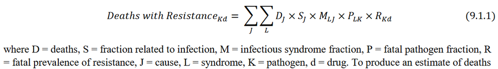

To produce an estimate of **deaths with resistance to any antibiotic** estimated, we employed the same formula but used the fatal prevalence of resistance to any antibiotic using the resistance profiles, described previously. 為了估計「對任何抗生素抗藥性的死亡人數」，使用了相同的計算公式，與使用了「對任何抗生素抗藥性的致死盛行率」

We calculated the **fatal prevalence of resistance R for a given drug *d*** based on the non-fatal prevalence of resistance **𝑅′** and relative risk of death **𝑅𝑅** for this drug: 為了估計「對**特定藥物**抗藥性的致死盛行率」，以「抗藥性的非致死盛行率𝑅′」和「死亡相對風險*RR」*做計算

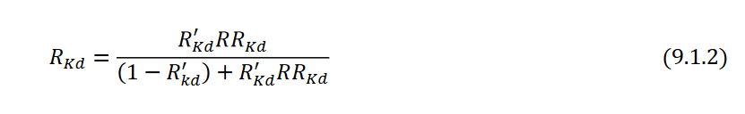

We calculated the **fatal prevalence of resistance to any antibiotic** estimated based on the non-fatal prevalences of each resistance profile, incorporating all resistance profiles **𝛿** that are resistant to at least 1 drug with corresponding relative risks **𝑅𝑅<sub>𝐾𝑑∗</sub>**<sub>.</sub> 為了估計「對**任何抗生素**抗藥性的致死盛行率」，計算「每一種抗藥性的非致命盛行率」，並包含「至少對一種藥物抗藥性的profiles 𝛿 」和「對應的相對風險𝑅𝑅<sub>𝐾𝑑∗</sub>」

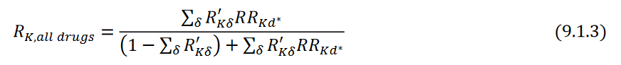

We then estimated **YLLs** using standard GBD methods to convert age-sex specific deaths into YLLs. 以標準GBD方法將特定年齡與性別的死亡轉為YLLs

For the **non-fatal estimate**, we first estimated the incidence of each infectious syndrome in each underlying cause. 為了「非致死估計」，首先計算「每一種死因每一種感染症候群的發生率」

For **infectious underlying causes** (table 9.1.1), we simply used the incidence estimated in GBD. 為了「感染死因」估計，使用了「在GBD內計算的發生率」

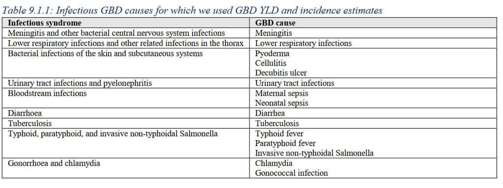

For **non-infectious underlying causes**, we divided the infectious syndrome deaths (𝐷<sub>𝑗</sub> × 𝑆<sub>𝐽</sub> × 𝑀<sub>𝐿𝐽</sub>) by the syndrome- and pathogen-specific CFRs calculated in section 5, aggregated across pathogen using the nonfatal pathogen distribution 𝑃′ calculated above. 為了「非感染死因」，將「感染症候群的死亡」除以「特定症候群和病原體的致死率」和「非致死病原體分布」

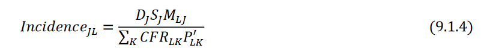

where D = deaths, S = fraction related to infection, M = infectious syndrome fraction

We then took the product of the infectious syndrome incidence, the non-fatal pathogen fraction, and the non-fatal prevalence of resistance and summed across all infectious syndromes and underlying causes to get **incidence with resistance for every pathogen and drug**. 為了取得「對每種病原體和藥物具有抗藥性的發病率」，計算「感染症候群發生率」、「非致命病原體比例」和「非致命抗藥性」的乘積

As with the fatal estimate, to produce an estimate of incident infections with resistance to any antibiotic, we used the same formula and used the non-fatal prevalence of resistance to any antibiotic estimated from the resistance profiles. 為了估計「對任何抗生素產生抗藥性的感染」，使用相同的公式，並使用「對任何抗生素抗藥性的非致死盛行率」

For all other causes, we multiplied together the **infectious syndrome incidence**, the **non-fatal pathogen fraction**, and a **syndrome-specific YLDs per incident case rate**, calculated using a proxy cause from GBD.[1] 對於其他死因，則是將「感染症候群發生率」、「非致死病原體比例」、「每個病例發生率的特定症候群的 YLDs」相乘

To estimate the YLDs per incident case rate, we extracted GBD incidence and YLD estimates for the proxy causes and divided the YLDs by the incidence for each age, sex, and location. 為了估計「每個病例發生率的 YLDs」，以「GBD incidence」 與「YLD估計」當作代理死因，並將YLDs根據每個年齡、性別和地區的發生率來劃分

To get the YLDs associated with resistance for each pathogen, we used the non-fatal prevalences of resistance for each drug and resistance profile and relative length of stay (LOS) for each pathogen–drug combination to calculate **the fraction of YLDs associated with resistance for each pathogen**, using equations analogous to equations 9.1.2 and 9.1.3. 為了得到「每一種病原體與抗體相關的YLDs」，使用「每一種藥物的非致命抗藥性盛行率」和「每一種病原體-藥物組合的相對停留時間」去計算「每一種病原體與抗藥性相關的YLDs比例」

**Length of stay (LOS)**

Length of stay (LOS) is a clinical metric that measures the time elapsed between a patient’s hospital admittance and discharge. 紀錄病患住院的時間長度

We multiplied this fraction by the YLDs for each pathogen to get **YLDs associated with resistance to each pathogen–drug combination** and **YLDs associated with resistance any antibiotics** estimated. 將上述計算比例與「每種病原體的YLDs」相乘，取得「每種病原體-藥物組合與抗藥性相關的YLDs」和「與任何抗生素抗藥性相關的YLDs」

We then added YLLs and YLDs to produce the DALY estimate for burden associated with resistance. 將YLLs和YLDs相加取得「與抗藥性相關負擔的DALY」

#### Estimating AMR burden with counterfactual of infection with susceptible organism

we first estimated the **population attributable fraction of deaths** (*Mortality PAF*) for each resistance profile with resistance to at least 1 drug, 𝛿. 首先估計「至少與一種藥物有抗藥性的*Mortality PAF*」

The inputs for the PAF were the non-fatal prevalence of the given resistance profile, 𝑅’<sub>𝐾𝛿</sub>, and the relative risk of death for resistant infection compared to susceptible infection for each drug, 𝑅𝑅<sub>𝑘𝑑</sub>. 以「特定抗藥性的非致命盛行率𝑅’<sub>𝐾𝛿</sub>」和「抗藥性感染的相對死亡風險𝑅𝑅<sub>𝑘𝑑</sub>」做計算

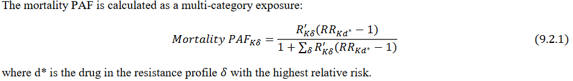

We then took the product of the deaths for each underlying cause, fraction of deaths related to infection, infectious syndrome fraction, fatal pathogen fraction, and the mortality PAF for each resistance profile to get the **deaths attributable to resistance for every resistance profile**: 為了取得「可歸因於抗藥性的死亡人數」，將「每種死因死亡人數」、「與感染相關死亡人數比例」、「感染症候群比例」、「致死病原體比例」、「死亡PAF 」相乘

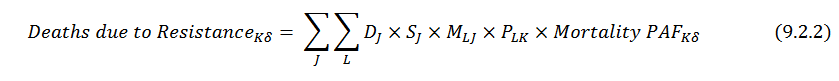

When the resistance profile described resistance to more than one antibiotic, the deaths were then distributed to the component pathogen–drug combinations based on the excess risk of the pathogen–drug combination divided by the sum of the excess risk of all pathogen–drug combinations in the resistance profile. For a resistance profile 𝛿 with resistance to drugs *i* = 1, … , *n*: 當對超過一種抗生素有抗藥性，根據病原體-藥物組合的超額風險除以抗藥性中所有病原體-藥物組合的超額風險總和，將死亡人數分配給病原體-藥物組合

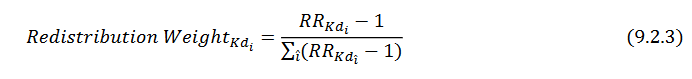

A similar approach was taken to estimate **non-fatal burden for the counterfactual of antibiotic-susceptible infection**. 以相似的方法估計「因抗生素敏感感染的非致命負擔」

We first assumed that antibiotic resistance has no effect on the attack rate of pathogens; therefore, there are 0 incident cases attributable to resistance and all non-fatal burden comes from increased length of illness. 假設抗生素抗藥性對病原體的攻擊率沒有影響，因此由抗藥性引起的病例為 0 ，所有非致命負擔均來自於患病時間的增加

To quantify the extent of this **increased length of illness**, we first produced a length of stay (LOS) PAF for each resistance profile using the non-fatal prevalence of resistance and relative LOS for resistant infections as compared to susceptible infections in a method analogous to equation 9.2.1. 為了計算增加的患病時間，首先使用「抗藥性的非致命盛行率」和「抗藥性感染相對LOS」，計算出每種抗藥性的停留時間(LOS) PAF

We then took the product of the YLDs for each infectious syndrome, the non-fatal pathogen distribution, and the LOS PAF to produce **attributable YLD estimates**. 為了估計「可歸因YLD」，將「每一種感染症候群的YLDs」、「非致命病原體分布」與「停留時間的PAF」相乘

We then added YLLs and YLDs to produce an estimate of **DALYs attributable to resistance**. 將YLLs和YLDs相加取得「可歸因於抗藥性的DALYs」